# Group 8 - Assignment 2

Group 8: Oskar Harmsen, Dennis Hansen, Ann-Sofie Hansen & Susanne Sundgaard Hansen

November 8 2015

# Introduction

In this assignment, we seek to provide insights on patterns in corruption across India. Our analyses are based on data from www.ipaidabrige.com, an online portal for reporting bribes paid. Specifically, we scrape the latest 1000 bribe reports from the site.

The assignment is written in R-markdown, and we’ve chosen to exhibit only the most relevant chunks of code in the html-document.

# Data scraping

In the Rmarkdown file our code for scraping is visible - to save time, we have provided the link to the most recent csv-file in our GitHub further below:

# Data cleaning

Some data cleaning is needed - luckily there are not too many spelling errors or mismatches since the “City”-box on the webpage is a dropdown-menu. However some of the amounts reported has erroneous decimals and are difficult to decipher, hence they are removed.

# Loading dataset

```r
df <- read.csv(file = "https://raw.githubusercontent.com/oskarharmsen/Assignment-2/master/assign2.csv",
               sep = ";")
names(df) <- c("date", "type", "town", "state", "views", "department", "currency", "paid", "title")
```

```r
#Correct classes of columns
  df$town <- str_trim(df$town)
  df$title <- str_trim(df$title)
  df$date <- as.Date(df$date)
  df$views <- as.numeric(df$views)
  df$paid <- as.numeric(df$paid)
  df$state <- str_trim(df$state)

#Remove NAs and Currency
  df <- df %>%
    select(-c(currency, title)) %>% #Remove irrelevant columns
    filter(!is.na(paid)) #Remove observations with NA in paid

  df <- df %>% filter(!is.na(state) & state!="") #Remove observations with NA or missing in state
```

# Descriptive Statistics

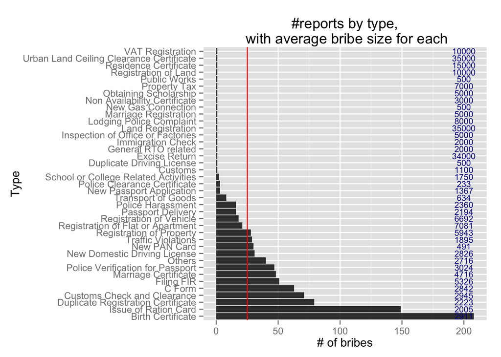

```r
# make an aggregate dataframe for types and # of bribes:

 agg <- df %>%
   group_by(type) %>%
   summarise( count = n(), mean = mean(paid), median = median(paid)) %>%
   arrange(-count)

  #Plot
   p <-  ggplot(agg, aes( x = reorder(type, -count), y = count)) +
         geom_bar(stat = "identity", fill = "black", alpha = 0.8) +
         geom_hline(y = mean(agg$count), colour = "red") +
         coord_flip() + labs( x = "Type", y = "# of bribes") +
         geom_text(aes(label = round(mean, digits = 0)),
                   size = 3, y = 200, colour = "darkblue")+
        ggtitle("#reports by type,\n with average bribe size for each")
   p
```

- birth certificates constitute most
- long tail
- most average bribes are between IRS 2000 and IRS 5000

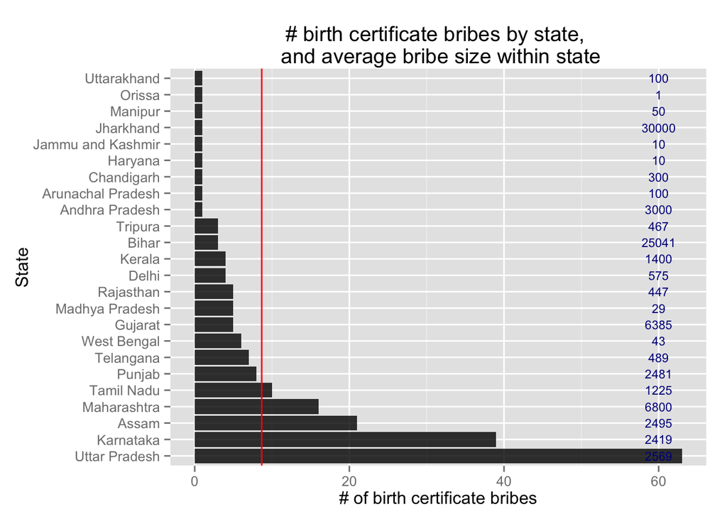

```r
# aggregate dataframe for birth certificate:

  #Create dataframe
  agg1 <- df %>%
  filter(paid != "NA", state != " ", type == "Birth Certificate") %>%
  group_by(state) %>%
  summarise( count = n(), mean = mean(paid)) %>%
  arrange(-count)

  # barplot showing the distribution of birth certificate reports by district:
   p <-  ggplot(agg1, aes( x = reorder(state, -count), y = count)) +
        geom_bar(stat = "identity", fill = "black", alpha = 0.8) +
        geom_hline(y = mean(agg1$count), colour = "red") +
        coord_flip() + labs( x = "State", y = "# of birth certificate bribes") +
        geom_text(aes(label = round(mean, digits = 0)), size = 3, y = 60, colour = "darkblue")+
        ggtitle("# birth certificate bribes by state, \n and average bribe size within state")
  p
```

# Mapping the data

```r
![Figure 1](https://raw.githubusercontent.com/oskarharmsen/Assignment-2/master/Maps.png?raw=true, "Figure 1")
```

[output not shown]

# Pairing with Indian demographic data

The code below shows how we load demographic state-level data for India from wikipedia, and merge it with our scraped dataset to be able to pursue greater insight into the determinants of corruption.

```r
# Get table from Wikipedia

  #Load website
  url <- "https://en.wikipedia.org/wiki/States_and_union_territories_of_India"
  tabs <- GET(url, encoding = "UTF-8")
  tabs <- readHTMLTable(rawToChar(tabs$content), stringsAsFactors = F, header = TRUE)

  #Reduce html-document to the relevant table
  tabs <- ldply(tabs[1:3]) #Only the first three elements of the list contain parts of the data
  tabs <- tabs[12:40,] #delete unnecessary rows
  tabs <- tabs[,-c(1:5)] #delete unnecessary columns

  #Clean the resulting table
  names(tabs) <- c("state", "code", "formation_date", "population", "area", "langugages", "capital",
                   "largest_city_if_not_capital", "population_density", "literacy",
                   "urban_population_share") #Naming the columns

  #Remove Wiki-links, percentages and NAs
  tabs <- as.data.frame(lapply(tabs, function(y) gsub(pattern = "\\[.*\\]", replacement =  "", x = y)))
  tabs <- as.data.frame(lapply(tabs, function(y) gsub(pattern = "\\%", replacement =  "", x = y)))
  tabs <- as.data.frame(lapply(tabs, function(y) gsub(pattern = "N\\/A", replacement =  NA, x = y)))

  #Convert numeric columns to numeric class
  tabs$literacy <- as.numeric(as.character(tabs$literacy))
  tabs$population_density <- as.numeric(as.character(tabs$population_density))
```

```r
  tabs$urban_population_share <- as.numeric(as.character(tabs$urban_population_share))

  #Change to earlier spelling method, to fit with ipaidabribe.com-data
  tabs$state <- gsub(x = tabs$state, pattern = "Odisha", replacement = "Orissa")

  #Remove irrelevant columns
  tabs <- tabs %>% select(state, population, literacy, population_density, urban_population_share)

  #Add demographic state-level data to each observation
  df <- left_join(df, tabs, by = "state")
```